# Exercise_2-1_s0572048

**Evaluated Exercise Part 2 – SciKit-Stack and Deep Learning**

- Tasks 3: SciKit Stack: Predict diamond prices [10%]
- Context:

You are working as Data Scientist for BeDeers. The company collected data about sold diamonds and their characteristics. Your job is to set up a model to look for possible influences on diamond price and to set up **(1) a multiple linear regression** and **(2) a random forest** to predict it.

- Dataset description: https://ggplot2.tidyverse.org/reference/diamonds.html
- Dataset: https://github.com/tidyverse/ggplot2/blob/master/data-raw/diamonds.csv Please read the dataset description first!
- Tasks: Please predict price (=> target variable)
  - Set up a new jupyter notebook
  - Import numpy, pandas, sklearn, matplotlib, searborn, ...
  - Use pandas and seaborn for visualization
  - Report all steps
  - Write a summary addressing management

## Import libraries

```python
import pandas as pd
import numpy as np
import itertools
import scipy.stats as ss
# Plotting : matplotlib & seaborn
import matplotlib.pyplot as plt
%matplotlib inline
import seaborn as sns
# Standardization
from sklearn.preprocessing import StandardScaler
# Data Preparation
from sklearn.model_selection import train_test_split
# Load Linear Regression model
from sklearn.linear_model import LinearRegression
from sklearn.metrics import r2_score, mean_squared_error, mean_absolute_error
from sklearn.ensemble import RandomForestRegressor
# Import Scikit-learn metrics module for accuracy calculation
from sklearn import metrics
# warnings
import warnings
warnings.filterwarnings('ignore')
# visualization
import plotly
plotly.offline.init_notebook_mode(connected=True)
import plotly.graph_objs as go
```

```python
# In order to run plotly, we need to install plotly into our pip
#!pip install plotly
```

## Data IO

```python
# Path to the data on the internet
url = "https://raw.githubusercontent.com/tidyverse/ggplot2/master/data-raw/diamonds.csv"
```

```python
# Use pandas read_csv to import the dataset
diamonds_raw = pd.read_csv(url)
```

## Data Understanding (EDA)

```python
# Take a look at the top 5 rows
diamonds_raw.head()
```

|  | carat | cut | color | clarity | depth | table | price | x | y | z |
| --- | --- | --- | --- | --- | --- | --- | --- | --- | --- | --- |
| 0 | 0.23 | Ideal | E | SI2 | 61.5 | 55.0 | 326 | 3.95 | 3.98 | 2.43 |
| 1 | 0.21 | Premium | E | SI1 | 59.8 | 61.0 | 326 | 3.89 | 3.84 | 2.31 |
| 2 | 0.23 | Good | E | VS1 | 56.9 | 65.0 | 327 | 4.05 | 4.07 | 2.31 |
| 3 | 0.29 | Premium | I | VS2 | 62.4 | 58.0 | 334 | 4.20 | 4.23 | 2.63 |
| 4 | 0.31 | Good | J | SI2 | 63.3 | 58.0 | 335 | 4.34 | 4.35 | 2.75 |

```python
# Take a look at the shape, our dataset has 53940 rows, 10 columns
diamonds_raw.shape
```

```
(53940, 10)
```

```python
# Take a look at the data datatypes and number of non-missing values
diamonds_raw.info()
```

```
<class 'pandas.core.frame.DataFrame'>
RangeIndex: 53940 entries, 0 to 53939
Data columns (total 10 columns):
 #   Column   Non-Null Count  Dtype
---  ------   --------------  -----
 0   carat    53940 non-null  float64
 1   cut      53940 non-null  object
 2   color    53940 non-null  object
 3   clarity  53940 non-null  object
 4   depth    53940 non-null  float64
 5   table    53940 non-null  float64
 6   price    53940 non-null  int64
 7   x        53940 non-null  float64
 8   y        53940 non-null  float64
 9   z        53940 non-null  float64
dtypes: float64(6), int64(1), object(3)
memory usage: 4.1+ MB
```

```python
# Get the summary statistics on numerical columns
diamonds_raw.describe().T
```

|  | count | mean | std | min | 25% | 50% | 75% | max |
| --- | --- | --- | --- | --- | --- | --- | --- | --- |
| carat | 53940.0 | 0.797940 | 0.474011 | 0.2 | 0.40 | 0.70 | 1.04 | 5.01 |
| depth | 53940.0 | 61.749405 | 1.432621 | 43.0 | 61.00 | 61.80 | 62.50 | 79.00 |
| table | 53940.0 | 57.457184 | 2.234491 | 43.0 | 56.00 | 57.00 | 59.00 | 95.00 |
| price | 53940.0 | 3932.799722 | 3989.439738 | 326.0 | 950.00 | 2401.00 | 5324.25 | 18823.00 |
| x | 53940.0 | 5.731157 | 1.121761 | 0.0 | 4.71 | 5.70 | 6.54 | 10.74 |
| y | 53940.0 | 5.734526 | 1.142135 | 0.0 | 4.72 | 5.71 | 6.54 | 58.90 |
| z | 53940.0 | 3.538734 | 0.705699 | 0.0 | 2.91 | 3.53 | 4.04 | 31.80 |

```python
# Get the summary look of categorical columns
diamonds_raw.describe(include = object).T
```

|  | count | unique | top | freq |
| --- | --- | --- | --- | --- |
| cut | 53940 | 5 | Ideal | 21551 |
| color | 53940 | 7 | G | 11292 |
| clarity | 53940 | 8 | SI1 | 13065 |

### Data Dictionary of 10 columns

- **price** (`Target Variable`): price in US dollars (\$326--\$18,823)
- **carat** : weight of the diamond (0.2--5.01)
- **cut** : quality of the cut (Fair, Good, Very Good, Premium, Ideal)
- **color** : diamond colour, from D (best) to J (worst)
- **clarity** : a measurement of how clear the diamond is (I1 (worst), SI2, SI1, VS2, VS1, VVS2, VVS1, IF (best))
- **x** : length in mm (0--10.74)
- **y** : width in mm (0--58.9)
- **z** : depth in mm (0--31.8)
- **depth** : total depth percentage = z / mean(x, y) = 2 * z / (x + y) (43--79)
- **table** : width of top of diamond relative to widest point (43--95)

```python
# Print out the number of unique values and take a look at first few entries
for column in diamonds_raw.columns:
  uniques = sorted(diamonds_raw[column].unique())
  print('{0:20s}{1:5d}\t'.format(column, len(uniques)),uniques[:9])
```

```
carat                 273	 [0.2, 0.21, 0.22, 0.23, 0.24, 0.25, 0.26, 0.27, 0.28]
cut                     5	 ['Fair', 'Good', 'Ideal', 'Premium', 'Very Good']
color                   7	 ['D', 'E', 'F', 'G', 'H', 'I', 'J']
clarity                 8	 ['I1', 'IF', 'SI1', 'SI2', 'VS1', 'VS2', 'VVS1', 'VVS2']
depth                 184	 [43.0, 44.0, 50.8, 51.0, 52.2, 52.3, 52.7, 53.0, 53.1]
table                 127	 [43.0, 44.0, 49.0, 50.0, 50.1, 51.0, 51.6, 52.0, 52.4]
price               11602	 [326, 327, 334, 335, 336, 337, 338, 339, 340]
x                     554	 [0.0, 3.73, 3.74, 3.76, 3.77, 3.79, 3.81, 3.82, 3.83]
y                     552	 [0.0, 3.68, 3.71, 3.72, 3.73, 3.75, 3.77, 3.78, 3.8]
z                     375	 [0.0, 1.07, 1.41, 1.53, 2.06, 2.24, 2.25, 2.26, 2.27]
```

### Categorical Variables (3)

- cut
- color
- clarity

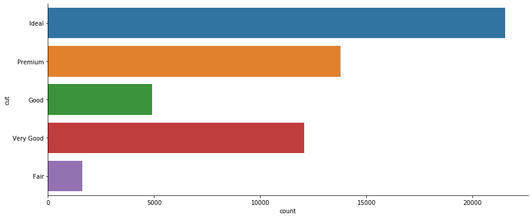

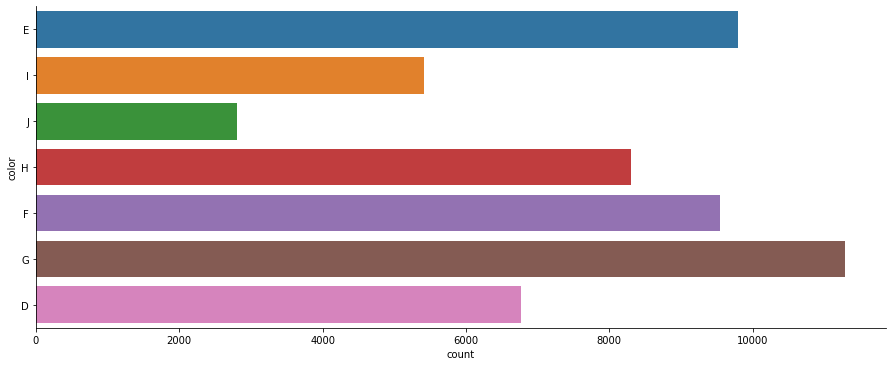

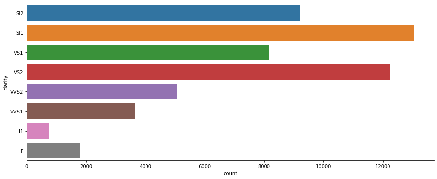

```python
# Plot the frequency plots of categorical variables
for feature in diamonds_raw.dtypes[diamonds_raw.dtypes == object].index:
  sns.factorplot(y = feature, data = diamonds_raw, kind = 'count', aspect = 2.5)
  plt.show()
```

```python
# Print the total number of unique categories
num_categories = len(diamonds_raw['cut'].unique())
print('Number of cut = ', num_categories)

# Count the number of apps in each 'Category'. Sort in descending order depending on number of apps in each category
num_apps_in_category = diamonds_raw['cut'].value_counts()

data = [go.Bar(
        x = num_apps_in_category.index, # index = category name
        y = num_apps_in_category.values, # value = count
)]

plotly.offline.iplot(data)
```

```
Number of cut =  5
```

[interactive chart not shown]

```python
# Using Plotly to draw the total number of unique categories
num_categories = len(diamonds_raw['color'].unique())
print('Number of Color = ', num_categories)

# Count the number of apps in each 'Category'. Sort in descending order depending on number of apps in each category
num_apps_in_category = diamonds_raw['color'].value_counts()

data = [go.Bar(
        x = num_apps_in_category.index, # index = category name
        y = num_apps_in_category.values, # value = count
)]

plotly.offline.iplot(data)
```

```
Number of Color =  7
```

[interactive chart not shown]

```python
# Print the total number of unique categories
num_categories = len(diamonds_raw['clarity'].unique())
print('Number of clarity = ', num_categories)

# Count the number of apps in each 'Category'. Sort in descending order depending on number of apps in each category
num_apps_in_category = diamonds_raw['clarity'].value_counts()

data = [go.Bar(
        x = num_apps_in_category.index, # index = category name
        y = num_apps_in_category.values, # value = count
)]

plotly.offline.iplot(data)
```

```
Number of clarity =  8
```

[interactive chart not shown]

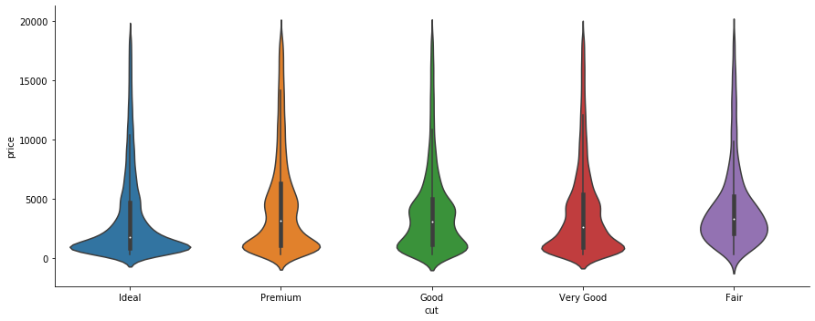

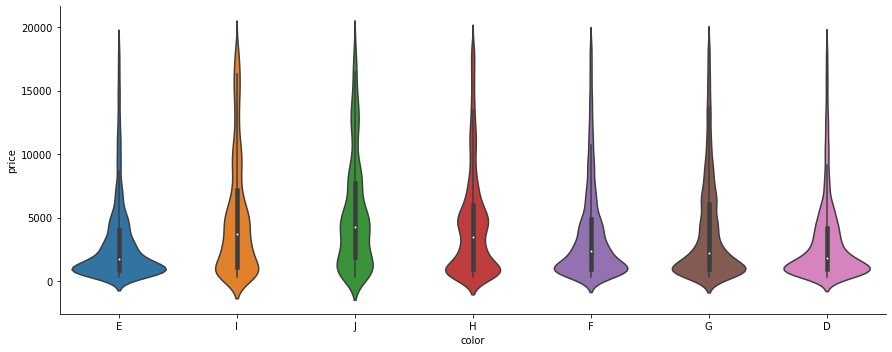

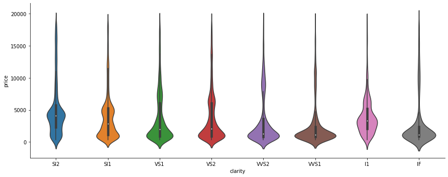

```python
# Violin plot to see the distribution of the datasets. can see where the majority of values lies
for feature in diamonds_raw.dtypes[diamonds_raw.dtypes == object].index:
  sns.factorplot(x = feature, y = 'price', data = diamonds_raw, kind = 'violin', aspect = 2.5)
  plt.show()
```

### Numerical Variables (7)

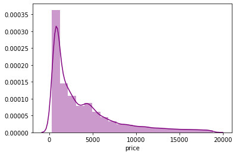

```python
# Histogram of the target numerical variable : price
sns.distplot(diamonds_raw.price, color = "purple", kde = True , bins = 20, label = "Histogram of Price")
```

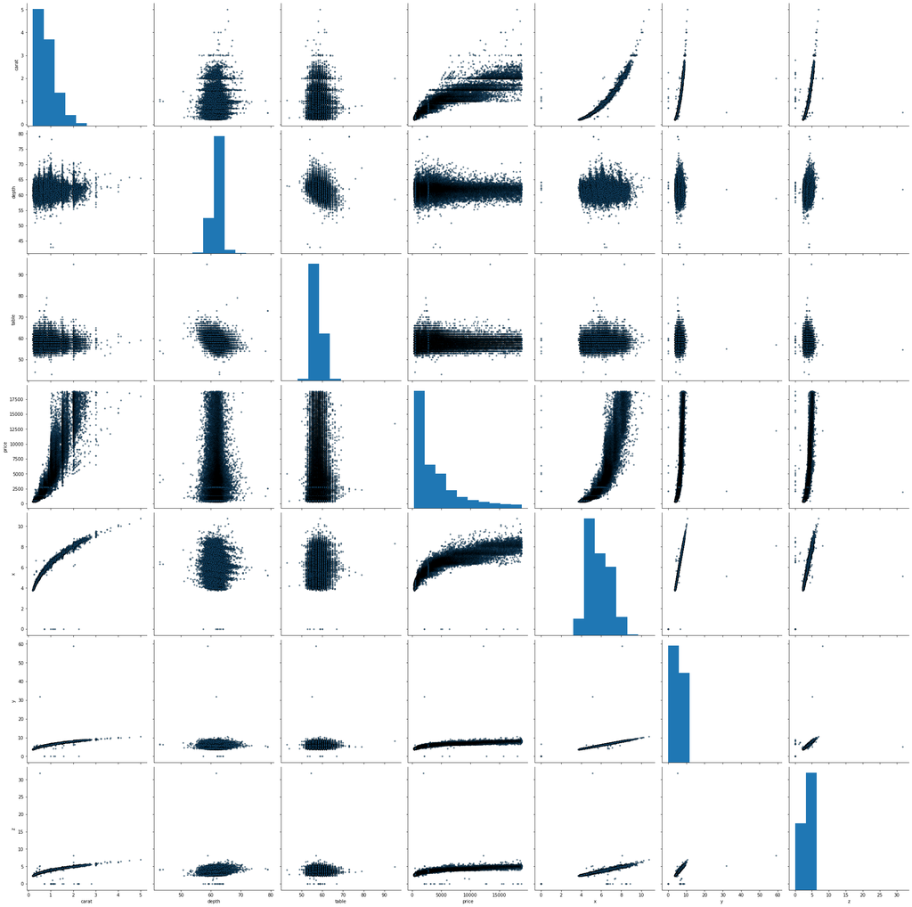

```python
# Pairplot to see the relationship between variables
p = sns.pairplot(diamonds_raw, plot_kws = {'alpha' : 0.6, 's': 8, 'edgecolor' : 'k'},
                 size = 4)
```

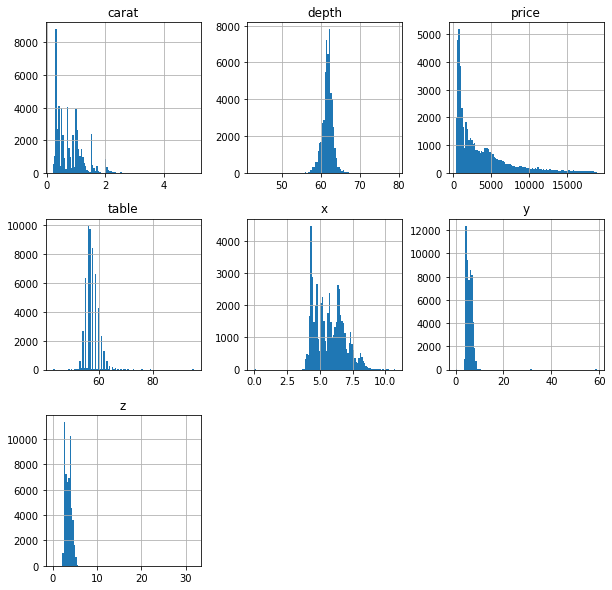

```python
# histogram of numerical variables
hist = diamonds_raw.hist(figsize = (10,10), bins = 100)
```

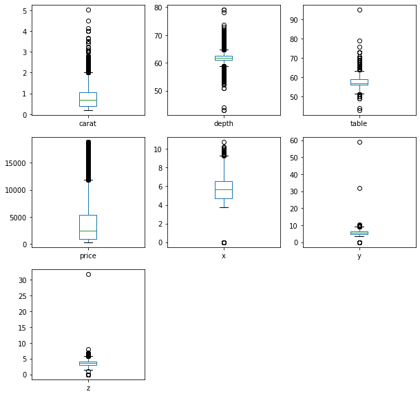

```python
# boxplot of numerical variables
diamonds_raw.plot(kind = 'box', figsize = (10,10), subplots = True, layout = (3,3))
plt.show()
```

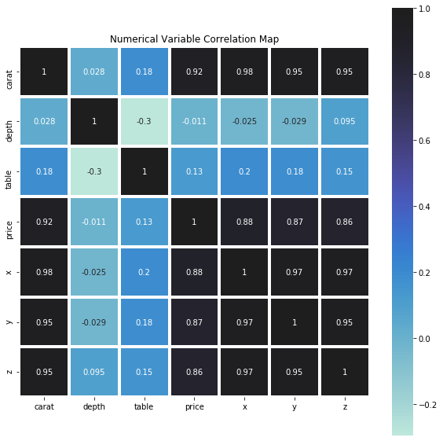

```python
# Numerical columns correlation table
# Price are highly correlated with Carat, x, y and z
plt.figure(figsize= (10, 10))
plt.title("Numerical Variable Correlation Map")
corr = diamonds_raw.corr()
sns.heatmap(data = corr, square = True, annot = True, cbar = True, center = 1, linewidth=3)
```

```python
# Function to plot categorical variables correlation plot
def cramers_corrected_stat(confusion_matrix):
    """ calculate Cramers V statistic for categorical-categorical association.
        uses correction from Bergsma and Wicher,
        Journal of the Korean Statistical Society 42 (2013): 323-328
    """
    chi2 = ss.chi2_contingency(confusion_matrix)[0]
    n = confusion_matrix.sum().sum()
    phi2 = chi2/n
    r,k = confusion_matrix.shape
    phi2corr = max(0, phi2 - ((k-1)*(r-1))/(n-1))
    rcorr = r - ((r-1)**2)/(n-1)
    kcorr = k - ((k-1)**2)/(n-1)
    return np.sqrt(phi2corr / min( (kcorr-1), (rcorr-1)))
```

```
Categorical Columns correlation of crashes data
```

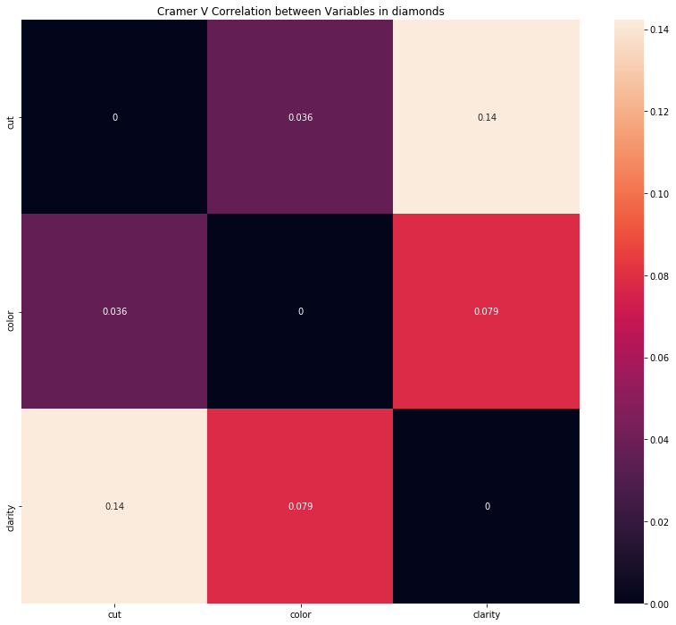

```python
# Categorical Columns of diamonds data
print("Categorical Columns correlation of crashes data")

cols = ["cut", "color", "clarity"]
corrM = np.zeros((len(cols),len(cols)))

for col1, col2 in itertools.combinations(cols, 2):
    idx1, idx2 = cols.index(col1), cols.index(col2)
    corrM[idx1, idx2] = cramers_corrected_stat(pd.crosstab(diamonds_raw[col1], diamonds_raw[col2]))
    corrM[idx2, idx1] = corrM[idx1, idx2]

corr = pd.DataFrame(corrM, index=cols, columns=cols)
fig, ax = plt.subplots(figsize=(14, 12))
ax = sns.heatmap(corr, annot=True, ax=ax); ax.set_title("Cramer V Correlation between Variables in diamonds");
```

## Data Preparation

- a. Missing Values
- b. Transformation of categorical variables (one-hot encoding)
- c. Split into train and test set

### a. Missing Values

```python
# No missing values/entries from isna()
diamonds_raw.isna().any()
```

```
carat      False
cut        False
color      False
clarity    False
depth      False
table      False
price      False
x          False
y          False
z          False
dtype: bool
```

#### x, y, z = 0 per definition should be 0 as it should be the length, width and depth

```python
# replace x = 0, y = 0, z = 0 with NaN and view it as missing values
diamonds_raw[['x','y','z']] = diamonds_raw[['x','y','z']].replace(0, np.NaN)
diamonds_raw.isnull().sum()
```

```
carat       0
cut         0
color       0
clarity     0
depth       0
table       0
price       0
x           8
y           7
z          20
dtype: int64
```

```python
# drop the missing values
diamonds_raw.dropna(inplace = True)
print("The sum of missing values:")
print("\n")
display(diamonds_raw.isnull().sum())
print("\n")
print("the modified shape: ", diamonds_raw.shape)
```

```
The sum of missing values:
```

```
carat      0
cut        0
color      0
clarity    0
depth      0
table      0
price      0
x          0
y          0
z          0
dtype: int64
```

```
the modified shape:  (53920, 10)
```

#### b. Transformation of categorical variables (one-hot encoding)

```python
# Take a look at the unique categories of each categorical variables
for i in ['cut','color','clarity']:
    print(diamonds_raw[i].unique())
```

```
['Ideal' 'Premium' 'Good' 'Very Good' 'Fair']
['E' 'I' 'J' 'H' 'F' 'G' 'D']
['SI2' 'SI1' 'VS1' 'VS2' 'VVS2' 'VVS1' 'I1' 'IF']
```

```python
# use one hot encoding to categorical columns
diamonds_en = pd.get_dummies(diamonds_raw)
```

```python
print("The shape after one-hot encoding:", diamonds_en.shape)
```

```
The shape after one-hot encoding: (53920, 27)
```

```python
diamonds_en.columns
```

```
Index(['carat', 'depth', 'table', 'price', 'x', 'y', 'z', 'cut_Fair',
       'cut_Good', 'cut_Ideal', 'cut_Premium', 'cut_Very Good', 'color_D',
       'color_E', 'color_F', 'color_G', 'color_H', 'color_I', 'color_J',
       'clarity_I1', 'clarity_IF', 'clarity_SI1', 'clarity_SI2', 'clarity_VS1',
       'clarity_VS2', 'clarity_VVS1', 'clarity_VVS2'],
      dtype='object')
```

```python
# add under score for column name
diamonds_en = diamonds_en.rename(columns={'cut_Very Good':'cut_Very_Good'})
```

```python
# double check whether it's added
diamonds_en.columns
```

```
Index(['carat', 'depth', 'table', 'price', 'x', 'y', 'z', 'cut_Fair',
       'cut_Good', 'cut_Ideal', 'cut_Premium', 'cut_Very_Good', 'color_D',
       'color_E', 'color_F', 'color_G', 'color_H', 'color_I', 'color_J',
       'clarity_I1', 'clarity_IF', 'clarity_SI1', 'clarity_SI2', 'clarity_VS1',
       'clarity_VS2', 'clarity_VVS1', 'clarity_VVS2'],
      dtype='object')
```

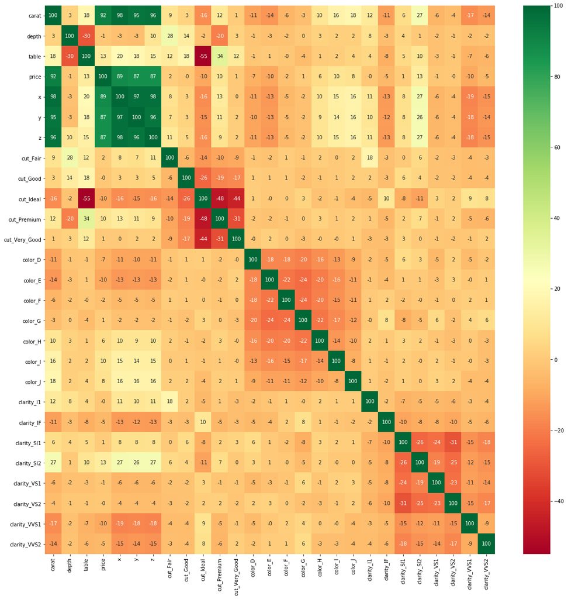

```python
# For Target variable : Price, it's highly correlated to price, x, y, z
plt.figure(figsize = (20,20))
corr1 = diamonds_en.corr()
sns.heatmap(corr1*100, cmap = "RdYlGn", annot = True, fmt = ".0f")
```

```python
diamonds_cat = diamonds_raw.select_dtypes(include = "object")
display(diamonds_cat['cut'].value_counts())
display(diamonds_cat['color'].value_counts())
diamonds_cat['clarity'].value_counts()
```

```
Ideal        21548
Premium      13780
Very Good    12081
Good          4902
Fair          1609
Name: cut, dtype: int64
```

```
G    11284
E     9797
F     9538
H     8298
D     6774
I     5421
J     2808
Name: color, dtype: int64
```

```
SI1     13063
VS2     12254
SI2      9185
VS1      8170
VVS2     5066
VVS1     3654
IF       1790
I1        738
Name: clarity, dtype: int64
```